# title: “Verkefni3”

# author: “Orri Leví Úlfarsson - olu2@hi.is”

# date: “March 12, 2018”

# output: html_document

# —

#### Byrja á því að setja inn pakkana sem eg ætla að nota

```r
library(ggplot2)
library(dplyr)
library(tidyr)
library(knitr)
```

#### og setja rÃ©tt directory

```r
setwd("/Users/orril/OneDrive/Skoli/Old/Líkindareikningur og Tölfræði/R")
```

# LiÃ°ur A

#### lesa inn skjaliÃ° husnaedi_stort.txt

```r
OLU <- read.table("husnaedi_stort.txt",header=TRUE,sep= ",")
```

#### lögum allt inní teg_eigna

```r
OLU$teg_eign <-as.factor(OLU$teg_eign)
levels(OLU$teg_eign)
```

```
##  [1] "ÃsamÃ¾ykkt ÃbÃºÃ°" "ÃbÃºÃ°areign"       "ÃbÃºÃ°arhÃºs"
##  [4] "EinbÃ½lishÃºs"       "FjÃ¶lbÃ½lishÃºs"     "GistihÃºs"
##  [7] "Gistiheimili"        "Herbergi"            "ParhÃºs"
## [10] "RaÃ°hÃºs"            "SÃ©reign"
```

```r
levels(OLU$teg_eign)<-c("ÃsamÃ¾ykktar","ÃbÃºÃ°areign","ÃbÃºÃ°arhÃºs", "EinbÃ½lishÃºs","FjÃ¶lbÃ½lishÃºs","GistihÃºs","Gistiheimili","herbergi", "ParhÃºs", "RaÃ°hÃºs","SÃ©reign")
levels(OLU$teg_eign)
```

```
##  [1] "ÃsamÃ¾ykktar"   "ÃbÃºÃ°areign"   "ÃbÃºÃ°arhÃºs"
##  [4] "EinbÃ½lishÃºs"   "FjÃ¶lbÃ½lishÃºs" "GistihÃºs"
##  [7] "Gistiheimili"    "herbergi"        "ParhÃºs"
## [10] "RaÃ°hÃºs"        "SÃ©reign"
```

#### lÃ¶gum kdagur

```r
str(OLU)
```

```
## 'data.frame':    35006 obs. of  21 variables:
##  $ ï..kdagur      : Factor w/ 1605 levels "1.1.2013","1.1.2014",..: 598 1267 1457 1457 1065 1168 1511 1303 1303 598 ...
##  $ nuvirdi        : int  18636 17533 14472 10186 14850 20831 34850 17992 13285 17134 ...
##  $ teg_eign       : Factor w/ 11 levels "ÃsamÃ¾ykktar",..: 2 2 2 1 2 2 4 2 2 2 ...
##  $ svfn           : int  0 0 0 0 0 0 6000 1000 1000 0 ...
##  $ byggar         : Factor w/ 141 levels "(null)","1846",..: 95 78 46 46 92 77 115 98 96 108 ...
##  $ mbstig         : int  7 7 7 7 7 7 7 7 7 7 ...
##  $ efstah         : int  3 2 2 2 3 3 1 4 8 3 ...
##  $ lyfta          : int  0 0 0 0 0 0 0 0 1 0 ...
##  $ ibm2           : num  117 67.9 45.7 43.8 78.1 87.4 125 89.5 44.9 69.2 ...
##  $ fjhaed         : int  1 1 1 1 1 1 1 1 1 1 ...
##  $ fjbilast       : int  0 0 0 0 0 0 0 0 0 0 ...
##  $ fjbkar         : int  1 0 0 0 1 1 1 1 1 1 ...
##  $ fjsturt        : int  0 1 1 1 0 0 1 0 0 1 ...
##  $ fjklos         : int  1 1 1 1 1 1 1 1 1 1 ...
##  $ fjeld          : int  1 1 1 1 1 1 1 1 1 1 ...
##  $ fjherb         : int  3 1 1 1 2 2 3 3 1 1 ...
##  $ fjstof         : int  1 1 1 1 1 1 1 1 1 1 ...
##  $ fjgeym         : int  2 1 0 0 1 2 0 1 1 2 ...
##  $ matssvaedi     : int  200 70 20 20 200 70 6040 320 320 220 ...
##  $ undirmatssvaedi: int  0 0 0 0 0 0 0 0 0 0 ...
##  $ ibteg          : int  12 12 12 12 12 12 11 12 12 12 ...
```

```r
names(OLU)[1]<-"kdagur"
```

#### tökum út allt sem er ekki Einbýlishús, Raðhús, Einbýlishús og Fjölbýlishús

```r
OLU <- subset(OLU, teg_eign == "ParhÃºs"|teg_eign =="RaÃ°hÃºs"|teg_eign =="EinbÃ½lishÃºs"|teg_eign =="FjÃ¶lbÃ½lishÃºs" )
OLU$teg_eign <- droplevels(OLU$teg_eign)
levels(OLU$teg_eign)
```

```
## [1] "EinbÃ½lishÃºs"   "FjÃ¶lbÃ½lishÃºs" "ParhÃºs"         "RaÃ°hÃºs"
```

#### FermetraverÃ° eigna = nuvirdi/ibm2

```r
OLU["fermetraverd"] <- round(OLU$nuvirdi / OLU$ibm2)
str(OLU)
```

```
## 'data.frame':    9744 obs. of  22 variables:
##  $ kdagur         : Factor w/ 1605 levels "1.1.2013","1.1.2014",..: 1511 1168 1511 1258 1168 123 1562 69 1511 1562 ...
##  $ nuvirdi        : int  34850 65933 57800 7992 22967 24165 37893 27454 13900 37344 ...
##  $ teg_eign       : Factor w/ 4 levels "EinbÃ½lishÃºs",..: 1 1 3 1 4 1 1 4 1 1 ...
##  $ svfn           : int  6000 0 1300 8716 0 3709 6000 6000 2506 1400 ...
##  $ byggar         : Factor w/ 141 levels "(null)","1846",..: 115 95 136 97 86 98 109 109 115 81 ...
##  $ mbstig         : int  7 7 7 7 7 7 7 7 7 7 ...
##  $ efstah         : int  1 1 1 1 2 1 1 2 2 1 ...
##  $ lyfta          : int  0 0 0 0 0 0 0 0 0 0 ...
##  $ ibm2           : num  125 197.1 162.5 105.4 86.4 ...
##  $ fjhaed         : int  1 1 1 1 2 2 1 2 2 2 ...
##  $ fjbilast       : int  0 0 0 0 0 0 0 0 0 0 ...
##  $ fjbkar         : int  1 0 0 0 1 1 1 1 1 1 ...
##  $ fjsturt        : int  1 0 1 1 0 0 1 1 1 0 ...
##  $ fjklos         : int  1 0 1 1 1 2 2 1 2 2 ...
##  $ fjeld          : int  1 0 1 1 1 2 1 1 1 1 ...
##  $ fjherb         : int  3 0 3 3 3 5 4 4 5 5 ...
##  $ fjstof         : int  1 0 2 1 1 2 1 2 2 3 ...
##  $ fjgeym         : int  0 0 1 1 0 0 0 0 1 2 ...
##  $ matssvaedi     : int  6040 280 530 8020 284 3110 6040 6040 2010 600 ...
##  $ undirmatssvaedi: int  0 31 0 0 0 0 0 0 0 0 ...
##  $ ibteg          : int  11 11 11 11 11 11 11 11 11 11 ...
##  $ fermetraverd   : num  279 335 356 76 266 133 258 178 82 239 ...
```

# LiÃ°ur B

#### hverfin okkar Mosfellsbær, Akranes og Fljótadalshérað

```r
hverfi<-c(800, 3000, 7035)
```

#### velja bara þau akvednu hverfi og gefum þeim nöfn

```r
OLU2 <-filter(OLU, matssvaedi %in% hverfi)
OLU2$matssvaedi <-as.factor(OLU2$matssvaedi)
levels(OLU2$matssvaedi)
```

```
## [1] "800"  "3000" "7035"
```

```r
levels(OLU2$matssvaedi)<-c("MosfellsbÃ¦r", "Akranes", "FljÃ³tadalshÃ©raÃ°")
```

#### Tafla sem sýnir fjöldan

```r
kable(table(OLU2$matssvaedi, OLU2$teg_eign),align = 'r', digits = 3)
```

|  | Einbýlishús | Fjölbýlishús | Parhús | Raðhús |
| --- | --- | --- | --- | --- |
| Mosfellsbær | 78 | 0 | 16 | 46 |
| Akranes | 194 | 0 | 23 | 64 |
| Fljótadalshérað | 7 | 0 | 0 | 0 |

#### Tafla sem sýnir hlutfallið

```r
kable(prop.table(table(OLU2$matssvaedi, OLU2$teg_eign),1), align = 'r', digits = 2)
```

|  | Einbýlishús | Fjölbýlishús | Parhús | Raðhús |
| --- | --- | --- | --- | --- |
| Mosfellsbær | 0.56 | 0 | 0.11 | 0.33 |
| Akranes | 0.69 | 0 | 0.08 | 0.23 |
| Fljótadalshérað | 1.00 | 0 | 0.00 | 0.00 |

#### Mynd sem sýnir fjölda eigna af hverri tegund

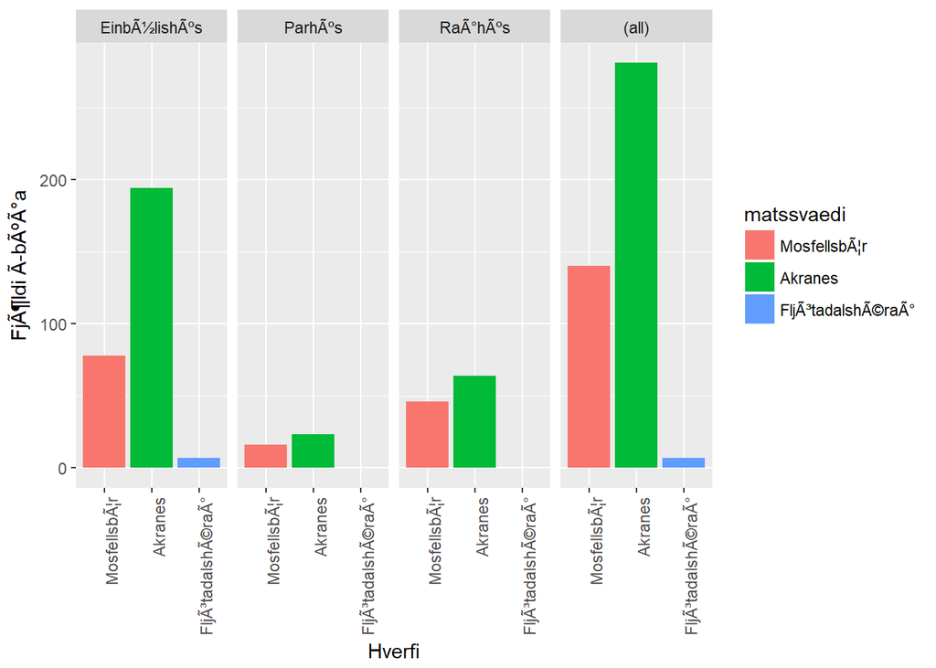

```r
ggplot(OLU2,aes(x=matssvaedi, fill=matssvaedi)) +
                  geom_bar() +
                  facet_grid(~teg_eign, margins= TRUE) +
                  xlab('Hverfi') +
                  ylab('FjÃ¶ldi ÃbÃºÃ°a') +
                  theme(axis.text.x = element_text(angle = 90, hjust = 1))
```

Hér er ekki tafla fyrir fjölbýlishús því það eru engin fjölbýlishús í hverfunum.

# LiÃ°ur C

#### Búum til nýja töflu

```r
OLU.rvk<-filter(OLU, svfn=="0")
```

#### BÃºum til breytuna

```r
OLU.rvk["ibm2.flokk"] <-  ifelse(OLU.rvk$ibm2<50, "mjÃ¶glitlar",
                          ifelse(OLU.rvk$ibm2<80, "litlar",
                          ifelse(OLU.rvk$ibm2<110, "miÃ°lungs",
                          ifelse(OLU.rvk$ibm2<140, "stÃ³rar",
                          ifelse(OLU.rvk$ibm2>=140, "mjÃ¶g stÃ³rar",
                                          NA  )))))
str(OLU.rvk$ibm2.flokk)
```

```
##  chr [1:1965] "mjÃ¶g stÃ³rar" "miÃ°lungs" "mjÃ¶g stÃ³rar" ...
```

#### Gerum tÃ¶fluna

```r
kable(OLU.rvk %>%
  group_by(teg_eign,ibm2.flokk) %>%
  dplyr::summarise(Medal_fermetraverd = mean(fermetraverd),
        Stadalfravik = sd(fermetraverd, na.rm= TRUE), fjoldi = n()), align = 'r', digits = 2)
```

| teg_eign | ibm2.flokk | Medal_fermetraverd | Stadalfravik | fjoldi |
| --- | --- | --- | --- | --- |
| Einbýlishús | litlar | 427.39 | 111.05 | 23 |
| Einbýlishús | miðlungs | 367.68 | 89.85 | 37 |
| Einbýlishús | mjög stórar | 305.40 | 93.63 | 708 |
| Einbýlishús | mjöglitlar | 489.75 | 207.99 | 4 |
| Einbýlishús | stórar | 357.55 | 71.82 | 128 |
| Fjölbýlishús | litlar | 649.50 | 241.12 | 2 |
| Fjölbýlishús | mjög stórar | 334.25 | 110.44 | 8 |
| Fjölbýlishús | stórar | 263.00 | NaN | 1 |
| Parhús | litlar | 329.31 | 67.62 | 13 |
| Parhús | miðlungs | 321.52 | 92.59 | 21 |
| Parhús | mjög stórar | 276.00 | 49.55 | 117 |
| Parhús | stórar | 324.95 | 76.88 | 43 |
| Raðhús | litlar | 371.12 | 141.89 | 8 |
| Raðhús | miðlungs | 350.88 | 84.97 | 78 |
| Raðhús | mjög stórar | 265.87 | 56.84 | 571 |
| Raðhús | stórar | 290.77 | 70.64 | 203 |

Flest hús falla undir stór eða mjög stór með þessari flokkun okkar. Einbýlishúsin eru þau einu sem koma í öllum mismunandi stærðunum. Það eru ekki til mjög lítil Fjölbýlishús, Parhús eða raðhús. Það eru engin miðlungs stór fjölbýlishús.

# LiÃ°ur D

#### Veljum hverfin

```r
OLU.Selja <-filter(OLU, matssvaedi %in% 150)
OLU.Holar <-filter(OLU, matssvaedi %in% 160)
set.seed(0510)
```

#### Veljum Eignir

```r
OLU.Selja.Sample <- sample_n(OLU.Selja, 50)
OLU.Holar.Sample <- sample_n(OLU.Holar, 50)
```

#### Sameinum

```r
OLU.HogS.Sample <- rbind(OLU.Holar.Sample, OLU.Selja.Sample)
str(OLU.HogS.Sample)
```

```
## 'data.frame':    100 obs. of  22 variables:
##  $ kdagur         : Factor w/ 1605 levels "1.1.2013","1.1.2014",..: 1422 554 1299 1007 1498 498 1446 1107 697 1603 ...
##  $ nuvirdi        : int  43886 18176 22832 42615 38539 31304 32378 49560 33486 46691 ...
##  $ teg_eign       : Factor w/ 4 levels "EinbÃ½lishÃºs",..: 1 4 4 1 1 4 1 1 4 1 ...
##  $ svfn           : int  0 0 0 0 0 0 0 0 0 0 ...
##  $ byggar         : Factor w/ 141 levels "(null)","1846",..: 99 114 114 99 98 106 98 98 106 102 ...
##  $ mbstig         : int  7 7 7 7 7 7 7 7 7 8 ...
##  $ efstah         : int  1 1 1 1 2 2 2 1 2 1 ...
##  $ lyfta          : int  0 0 0 0 0 0 0 0 0 0 ...
##  $ ibm2           : num  142 85 85 249 148 ...
##  $ fjhaed         : int  1 1 1 2 2 2 2 2 2 2 ...
##  $ fjbilast       : int  0 0 0 0 0 0 0 0 0 0 ...
##  $ fjbkar         : int  1 1 1 1 1 1 1 1 1 2 ...
##  $ fjsturt        : int  1 0 0 2 1 0 2 0 0 0 ...
##  $ fjklos         : int  2 1 1 2 2 2 2 2 2 3 ...
##  $ fjeld          : int  1 1 1 1 1 1 1 1 1 1 ...
##  $ fjherb         : int  0 2 2 7 4 4 4 5 4 7 ...
##  $ fjstof         : int  2 1 1 2 1 2 1 2 2 3 ...
##  $ fjgeym         : int  0 0 0 0 1 0 0 0 0 0 ...
##  $ matssvaedi     : int  160 160 160 160 160 160 160 160 160 160 ...
##  $ undirmatssvaedi: int  21 0 0 0 0 0 0 21 0 0 ...
##  $ ibteg          : int  11 11 11 11 11 11 11 11 11 11 ...
##  $ fermetraverd   : num  308 214 269 171 261 251 221 266 269 161 ...
```

# LiÃ°ur E

#### Tilgáturnar mínar eru:

Áður en við förum að gera svokallaða t.prófun á muninum á tveim óháðum meðaltölum könnum við hvort að $\sigma_1^2 = \sigma_2^2$ eða hvort að $\sigma_1^2 \neq \sigma_2^2$ $Núlltilgátan \space er, \space H_0: \mu_1 - \mu_2 = 0$ sem væri þá $H_0: \sigma_1^2 = \sigma_2^2$

$Gagntilgátan\space er, \space H_1: \mu_1 - \mu_2 \neq 0$ sem væri þá $H_1: \sigma_1^2 \neq \sigma_2^2$

Þar sem $\sigma_1^2$ er dreifni fermetraverðs í Seljahverfi og $\sigma_2^2$ er dreifni fermetraverðs í Hólar og Berg.

#### Gerum bartlett prÃ³fun

```r
bartlett <- c<-bartlett.test(fermetraverd ~ matssvaedi, data = OLU.HogS.Sample)
bartlett
```

```
##
##  Bartlett test of homogeneity of variances
##
## data:  fermetraverd by matssvaedi
## Bartlett's K-squared = 4.4482, df = 1, p-value = 0.03494
```

Þá höfum við sannað að $H_0$ sé ekki endilega satt og gerum því ráð fyrir að dreifni fermetraverðsins sé ekki það sama út frá Bartlett prófinu.

#### Gerum annað próf

```r
Prof.1 <- t.test(fermetraverd ~ matssvaedi,
                   var.equal = FALSE, data=OLU.HogS.Sample)
Prof.1
```

```
##
##  Welch Two Sample t-test
##
## data:  fermetraverd by matssvaedi
## t = 0.1028, df = 90.104, p-value = 0.9184
## alternative hypothesis: true difference in means is not equal to 0
## 95 percent confidence interval:
##  -19.79185  21.95185
## sample estimates:
## mean in group 150 mean in group 160
##            243.44            242.36
```

Prófstærðin okkar er 0.103. P.gildið sem er reiknað útfrá gildi prófstærðarinnar er $p$ = 0.9183521. Öryggisbil fyrir mismun meðaltalanna tveggja er -19.792, 21.952 út frá gefnum upplýsingum drögum við þá ályktun að munurinn er mögulega = 0 og höfum þá sannað $H_0$

# LiÃ°ur F

#### BÃºum til breytuna

```r
OLU.HogS.Sample["erbadkar"] <-  ifelse(OLU.HogS.Sample$fjbkar==0, "NEI",
                                ifelse(OLU.HogS.Sample$fjbkar>0, "JÃ",
                                          NA  ))

kable(table(OLU.HogS.Sample$erbadkar),align="c", digits = 3)
```

| Var1 | Freq |
| --- | --- |
| JÃ | 96 |
| NEI | 4 |

#### Skoðum aðeins gögnin og undirbúm prófið

```r
kable(table(OLU.HogS.Sample$matssvaedi,OLU.HogS.Sample$erbadkar),align = 'l', digits = 3)
```

|  | JÃ | NEI |
| --- | --- | --- |
| 150 | 46 | 4 |
| 160 | 50 | 0 |

```r
kable(prop.table(table(OLU.HogS.Sample$matssvaedi,OLU.HogS.Sample$erbadkar), margin = 1),align="l", digits = 3)
```

|  | JÃ | NEI |
| --- | --- | --- |
| 150 | 0.92 | 0.08 |
| 160 | 1.00 | 0.00 |

```r
p.test <- prop.test(table(OLU.HogS.Sample$matssvaedi,OLU.HogS.Sample$erbadkar))
```

Við gerum prop.test() skipun, til að sjá hvort að það sé munur á hlutfalli eigna með baðkari í hverfunum. Þar sem $p_S$ er hlutfall eigna í Seljahverfi sem ekki eru með baðkar og $p_H$ er hlutfall eigna í Hóla hverfi sem ekki eru með baðkar.

$$H_0: p_S - p_H = 0$$
$$H_1:p_S - p_H \neq 0$$

```r
p.test
```

```
##
##  2-sample test for equality of proportions with continuity
##  correction
##
## data:  table(OLU.HogS.Sample$matssvaedi, OLU.HogS.Sample$erbadkar)
## X-squared = 2.3437, df = 1, p-value = 0.1258
## alternative hypothesis: two.sided
## 95 percent confidence interval:
##  -0.17519726  0.01519726
## sample estimates:
## prop 1 prop 2
##   0.92   1.00
```

Prófið er með prófstærð = 2.344 með $(r-1)(s-1)=(2-1)(2-1)=1$ frígráðu og p.gildi reiknað útfrá gildi prófstærðarinnar er $p$ = 0.126. Öryggisbil fyrir mismun hlutfallana tveggja er -0.175, 0.015. Við sjáum bæði á öryggisbilinu og út frá p.gildinu $>.05$ sem eru þau $\alpha$ mörk sem við gáfum okkur í upphafi, að samkvæmt gefnum upplýsingum höfnum við ekki $H_0$ og gerum þá ráð fyrir því að það sé enginn munur á milli hlutfalla eigna sme hafa baðkar og þeirra sem hafa það ekki í hverfunum tveimur. Við þessu mátti búast eftir forskoðun gaagnanna þar sem þar sést að aðeins 4 hús í öðru hverfinu eru ekki með baðkar en öll húin í hinu hverfinu er með baðkar

# LiÃ°ur G

#### Teiknum myndina

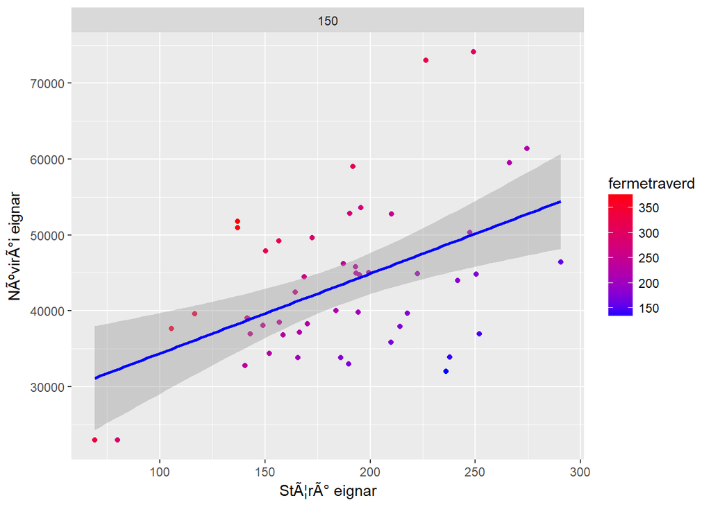

```r
ggplot(OLU.Selja.Sample, aes(x=ibm2, y=nuvirdi, colour="purple")) +
              geom_point(aes(colour=fermetraverd)) +
              scale_color_gradient(low = "blue", high = "red", name="fermetraverd") +
              xlab('StÃ¦rÃ° eignar') +
              ylab('NÃºvirÃ°i eignar') +
              facet_grid(~matssvaedi) +
              geom_smooth(method = "lm",colour="blue")
```